# 13_binomial_exact_approx

## 13_binomial_exact_approx

#### Question

1. Tyler has a 77% chance to hit each freethrow (so $p=0.77$). Each freethrow is [independent](https://en.wikipedia.org/wiki/Independent_and_identically_distributed_random_variables).

   Each day, Tyler attempts $n=30$ freethrows. Each success gets 1 point. Each failure gets 0 points.

   We can predict the distribution of points per day . We will use 2 strategies:
   - An exact [binomial distribution](https://en.wikipedia.org/wiki/Binomial_distribution).
   - A normal approximation.

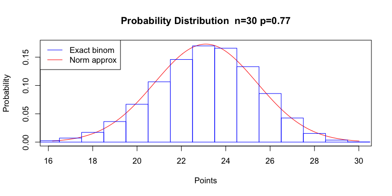

   - We can set up the exact binomial in [Desmos](https://www.desmos.com/calculator) using `binomialdist(30,0.77)`

   To set up the normal approximation, we need to find the mean and the standard deviation.

   $$\mu = np$$
   $$\sigma = \sqrt{np(1-p)}$$
   - Once you get $\mu$ and $\sigma$, you can set up the normal approximation in [Desmos](https://www.desmos.com/calculator) using `normaldist(`$\mu$`,`$\sigma$`)`

   Please find the following probabilities:
   1. Using the exact binomial, calculate $P(X<22.5)$.
   2. Using the normal approximation, calculate $P(X<22.5)$.
   3. Using the exact binomial, calculate $P(X>26.5)$.
   4. Using the normal approximation, calculate $P(X>26.5)$.
   5. Using the exact binomial, calculate $P(18.5<X<22.5)$.
   6. Using the normal approximation, calculate $P(18.5<X<22.5)$.

   *(Notice I already gave [half-integer](https://en.wikipedia.org/wiki/Half-integer) boundaries for the [continuity correction](https://en.wikipedia.org/wiki/Continuity_correction).)*

#### Question

2. Tyler has a 37% chance to hit each freethrow (so $p=0.37$). Each freethrow is [independent](https://en.wikipedia.org/wiki/Independent_and_identically_distributed_random_variables).

   Each day, Tyler attempts $n=30$ freethrows. Each success gets 1 point. Each failure gets 0 points.

   We can predict the distribution of points per day . We will use 2 strategies:
   - An exact [binomial distribution](https://en.wikipedia.org/wiki/Binomial_distribution).
   - A normal approximation.

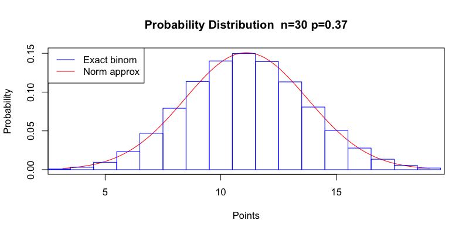

   - We can set up the exact binomial in [Desmos](https://www.desmos.com/calculator) using `binomialdist(30,0.37)`

   To set up the normal approximation, we need to find the mean and the standard deviation.

   $$\mu = np$$
   $$\sigma = \sqrt{np(1-p)}$$
   - Once you get $\mu$ and $\sigma$, you can set up the normal approximation in [Desmos](https://www.desmos.com/calculator) using `normaldist(`$\mu$`,`$\sigma$`)`

   Please find the following probabilities:
   1. Using the exact binomial, calculate $P(X<9.5)$.
   2. Using the normal approximation, calculate $P(X<9.5)$.
   3. Using the exact binomial, calculate $P(X>5.5)$.
   4. Using the normal approximation, calculate $P(X>5.5)$.
   5. Using the exact binomial, calculate $P(8.5<X<11.5)$.
   6. Using the normal approximation, calculate $P(8.5<X<11.5)$.

   *(Notice I already gave [half-integer](https://en.wikipedia.org/wiki/Half-integer) boundaries for the [continuity correction](https://en.wikipedia.org/wiki/Continuity_correction).)*

#### Question

3. Tyler has a 37% chance to hit each freethrow (so $p=0.37$). Each freethrow is [independent](https://en.wikipedia.org/wiki/Independent_and_identically_distributed_random_variables).

   Each day, Tyler attempts $n=20$ freethrows. Each success gets 1 point. Each failure gets 0 points.

   We can predict the distribution of points per day . We will use 2 strategies:
   - An exact [binomial distribution](https://en.wikipedia.org/wiki/Binomial_distribution).
   - A normal approximation.

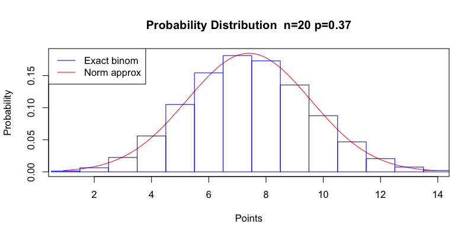

   - We can set up the exact binomial in [Desmos](https://www.desmos.com/calculator) using `binomialdist(20,0.37)`

   To set up the normal approximation, we need to find the mean and the standard deviation.

   $$\mu = np$$
   $$\sigma = \sqrt{np(1-p)}$$
   - Once you get $\mu$ and $\sigma$, you can set up the normal approximation in [Desmos](https://www.desmos.com/calculator) using `normaldist(`$\mu$`,`$\sigma$`)`

   Please find the following probabilities:
   1. Using the exact binomial, calculate $P(X<7.5)$.
   2. Using the normal approximation, calculate $P(X<7.5)$.
   3. Using the exact binomial, calculate $P(X>8.5)$.
   4. Using the normal approximation, calculate $P(X>8.5)$.
   5. Using the exact binomial, calculate $P(5.5<X<10.5)$.
   6. Using the normal approximation, calculate $P(5.5<X<10.5)$.

   *(Notice I already gave [half-integer](https://en.wikipedia.org/wiki/Half-integer) boundaries for the [continuity correction](https://en.wikipedia.org/wiki/Continuity_correction).)*

#### Question

4. Tyler has a 83% chance to hit each freethrow (so $p=0.83$). Each freethrow is [independent](https://en.wikipedia.org/wiki/Independent_and_identically_distributed_random_variables).

   Each day, Tyler attempts $n=40$ freethrows. Each success gets 1 point. Each failure gets 0 points.

   We can predict the distribution of points per day . We will use 2 strategies:
   - An exact [binomial distribution](https://en.wikipedia.org/wiki/Binomial_distribution).
   - A normal approximation.

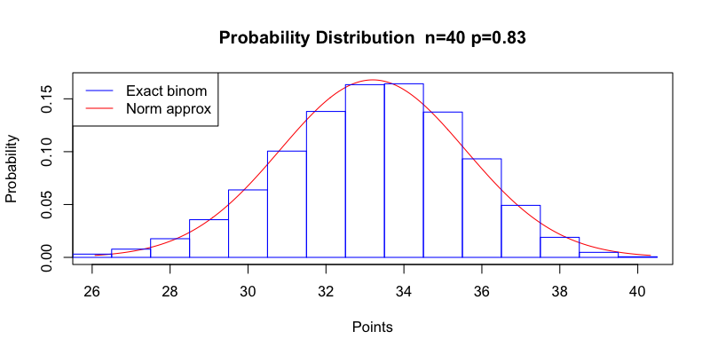

   - We can set up the exact binomial in [Desmos](https://www.desmos.com/calculator) using `binomialdist(40,0.83)`

   To set up the normal approximation, we need to find the mean and the standard deviation.

   $$\mu = np$$
   $$\sigma = \sqrt{np(1-p)}$$
   - Once you get $\mu$ and $\sigma$, you can set up the normal approximation in [Desmos](https://www.desmos.com/calculator) using `normaldist(`$\mu$`,`$\sigma$`)`

   Please find the following probabilities:
   1. Using the exact binomial, calculate $P(X<31.5)$.
   2. Using the normal approximation, calculate $P(X<31.5)$.
   3. Using the exact binomial, calculate $P(X>33.5)$.
   4. Using the normal approximation, calculate $P(X>33.5)$.
   5. Using the exact binomial, calculate $P(30.5<X<34.5)$.
   6. Using the normal approximation, calculate $P(30.5<X<34.5)$.

   *(Notice I already gave [half-integer](https://en.wikipedia.org/wiki/Half-integer) boundaries for the [continuity correction](https://en.wikipedia.org/wiki/Continuity_correction).)*

#### Question

5. Tyler has a 75% chance to hit each freethrow (so $p=0.75$). Each freethrow is [independent](https://en.wikipedia.org/wiki/Independent_and_identically_distributed_random_variables).

   Each day, Tyler attempts $n=50$ freethrows. Each success gets 1 point. Each failure gets 0 points.

   We can predict the distribution of points per day . We will use 2 strategies:
   - An exact [binomial distribution](https://en.wikipedia.org/wiki/Binomial_distribution).
   - A normal approximation.

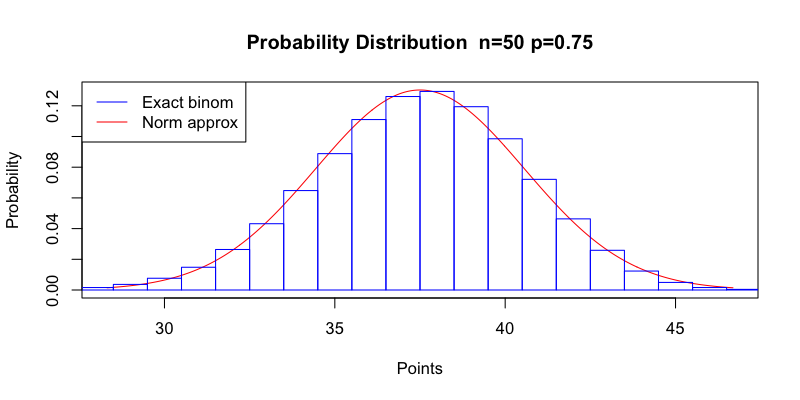

   - We can set up the exact binomial in [Desmos](https://www.desmos.com/calculator) using `binomialdist(50,0.75)`

   To set up the normal approximation, we need to find the mean and the standard deviation.

   $$\mu = np$$
   $$\sigma = \sqrt{np(1-p)}$$
   - Once you get $\mu$ and $\sigma$, you can set up the normal approximation in [Desmos](https://www.desmos.com/calculator) using `normaldist(`$\mu$`,`$\sigma$`)`

   Please find the following probabilities:
   1. Using the exact binomial, calculate $P(X<37.5)$.
   2. Using the normal approximation, calculate $P(X<37.5)$.
   3. Using the exact binomial, calculate $P(X>42.5)$.
   4. Using the normal approximation, calculate $P(X>42.5)$.
   5. Using the exact binomial, calculate $P(33.5<X<43.5)$.
   6. Using the normal approximation, calculate $P(33.5<X<43.5)$.

   *(Notice I already gave [half-integer](https://en.wikipedia.org/wiki/Half-integer) boundaries for the [continuity correction](https://en.wikipedia.org/wiki/Continuity_correction).)*

#### Question

6. Tyler has a 73% chance to hit each freethrow (so $p=0.73$). Each freethrow is [independent](https://en.wikipedia.org/wiki/Independent_and_identically_distributed_random_variables).

   Each day, Tyler attempts $n=60$ freethrows. Each success gets 1 point. Each failure gets 0 points.

   We can predict the distribution of points per day . We will use 2 strategies:
   - An exact [binomial distribution](https://en.wikipedia.org/wiki/Binomial_distribution).
   - A normal approximation.

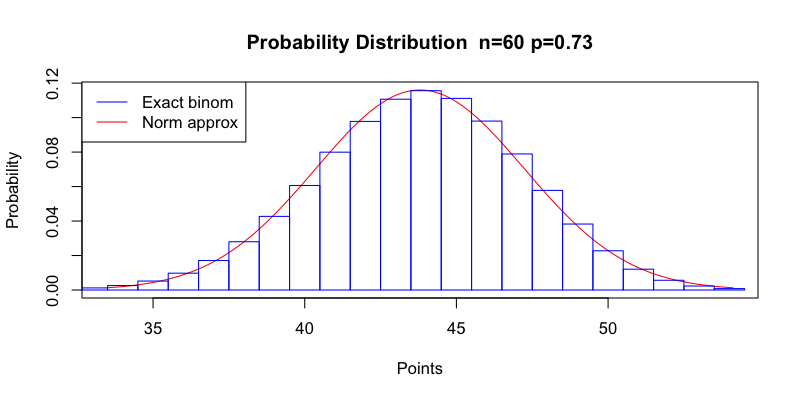

   - We can set up the exact binomial in [Desmos](https://www.desmos.com/calculator) using `binomialdist(60,0.73)`

   To set up the normal approximation, we need to find the mean and the standard deviation.

   $$\mu = np$$
   $$\sigma = \sqrt{np(1-p)}$$
   - Once you get $\mu$ and $\sigma$, you can set up the normal approximation in [Desmos](https://www.desmos.com/calculator) using `normaldist(`$\mu$`,`$\sigma$`)`

   Please find the following probabilities:
   1. Using the exact binomial, calculate $P(X<41.5)$.
   2. Using the normal approximation, calculate $P(X<41.5)$.
   3. Using the exact binomial, calculate $P(X>37.5)$.
   4. Using the normal approximation, calculate $P(X>37.5)$.
   5. Using the exact binomial, calculate $P(37.5<X<42.5)$.
   6. Using the normal approximation, calculate $P(37.5<X<42.5)$.

   *(Notice I already gave [half-integer](https://en.wikipedia.org/wiki/Half-integer) boundaries for the [continuity correction](https://en.wikipedia.org/wiki/Continuity_correction).)*

#### Question

7. Tyler has a 28% chance to hit each freethrow (so $p=0.28$). Each freethrow is [independent](https://en.wikipedia.org/wiki/Independent_and_identically_distributed_random_variables).

   Each day, Tyler attempts $n=60$ freethrows. Each success gets 1 point. Each failure gets 0 points.

   We can predict the distribution of points per day . We will use 2 strategies:
   - An exact [binomial distribution](https://en.wikipedia.org/wiki/Binomial_distribution).
   - A normal approximation.

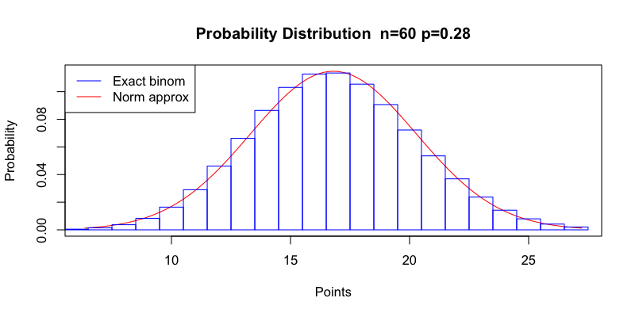

   - We can set up the exact binomial in [Desmos](https://www.desmos.com/calculator) using `binomialdist(60,0.28)`

   To set up the normal approximation, we need to find the mean and the standard deviation.

   $$\mu = np$$
   $$\sigma = \sqrt{np(1-p)}$$
   - Once you get $\mu$ and $\sigma$, you can set up the normal approximation in [Desmos](https://www.desmos.com/calculator) using `normaldist(`$\mu$`,`$\sigma$`)`

   Please find the following probabilities:
   1. Using the exact binomial, calculate $P(X<23.5)$.
   2. Using the normal approximation, calculate $P(X<23.5)$.
   3. Using the exact binomial, calculate $P(X>11.5)$.
   4. Using the normal approximation, calculate $P(X>11.5)$.
   5. Using the exact binomial, calculate $P(15.5<X<19.5)$.
   6. Using the normal approximation, calculate $P(15.5<X<19.5)$.

   *(Notice I already gave [half-integer](https://en.wikipedia.org/wiki/Half-integer) boundaries for the [continuity correction](https://en.wikipedia.org/wiki/Continuity_correction).)*

#### Question

8. Tyler has a 23% chance to hit each freethrow (so $p=0.23$). Each freethrow is [independent](https://en.wikipedia.org/wiki/Independent_and_identically_distributed_random_variables).

   Each day, Tyler attempts $n=70$ freethrows. Each success gets 1 point. Each failure gets 0 points.

   We can predict the distribution of points per day . We will use 2 strategies:
   - An exact [binomial distribution](https://en.wikipedia.org/wiki/Binomial_distribution).
   - A normal approximation.

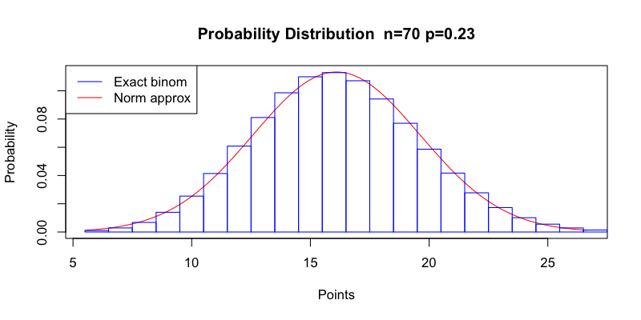

   - We can set up the exact binomial in [Desmos](https://www.desmos.com/calculator) using `binomialdist(70,0.23)`

   To set up the normal approximation, we need to find the mean and the standard deviation.

   $$\mu = np$$
   $$\sigma = \sqrt{np(1-p)}$$
   - Once you get $\mu$ and $\sigma$, you can set up the normal approximation in [Desmos](https://www.desmos.com/calculator) using `normaldist(`$\mu$`,`$\sigma$`)`

   Please find the following probabilities:
   1. Using the exact binomial, calculate $P(X<14.5)$.
   2. Using the normal approximation, calculate $P(X<14.5)$.
   3. Using the exact binomial, calculate $P(X>18.5)$.
   4. Using the normal approximation, calculate $P(X>18.5)$.
   5. Using the exact binomial, calculate $P(9.5<X<15.5)$.
   6. Using the normal approximation, calculate $P(9.5<X<15.5)$.

   *(Notice I already gave [half-integer](https://en.wikipedia.org/wiki/Half-integer) boundaries for the [continuity correction](https://en.wikipedia.org/wiki/Continuity_correction).)*